# Automatic and manual transmission relation with miles er gallon (MPG) consumption

j-ros

## Summary

In this report we are going to analise and quantify the relation between type of transmission (automatic or manual) with the fuel consumption in miles per gallon (mpg) using the mtcars dataset in R. This dataset comprises data for 32 automobile models from 1973-1974 and was extracted from the 1974 Motor Trend US magazine.

## Analysis

### Data exploration

First we are going to explore the dataset and the variables that are contained in it. We can see that from the 32 car models, 19 are automatic while 13 are manual and that the mpg ranges from 10.40 to 33.90 miles per gallon.

```r
data(mtcars)
str(mtcars)
```

```
## 'data.frame':    32 obs. of  11 variables:
##  $ mpg : num  21 21 22.8 21.4 18.7 18.1 14.3 24.4 22.8 19.2 ...
##  $ cyl : num  6 6 4 6 8 6 8 4 4 6 ...
##  $ disp: num  160 160 108 258 360 ...
##  $ hp  : num  110 110 93 110 175 105 245 62 95 123 ...
##  $ drat: num  3.9 3.9 3.85 3.08 3.15 2.76 3.21 3.69 3.92 3.92 ...
##  $ wt  : num  2.62 2.88 2.32 3.21 3.44 ...
##  $ qsec: num  16.5 17 18.6 19.4 17 ...
##  $ vs  : num  0 0 1 1 0 1 0 1 1 1 ...
##  $ am  : num  1 1 1 0 0 0 0 0 0 0 ...
##  $ gear: num  4 4 4 3 3 3 3 4 4 4 ...
##  $ carb: num  4 4 1 1 2 1 4 2 2 4 ...
```

```r
summary(mtcars)
```

```
##       mpg             cyl             disp             hp
##  Min.   :10.40   Min.   :4.000   Min.   : 71.1   Min.   : 52.0
##  1st Qu.:15.43   1st Qu.:4.000   1st Qu.:120.8   1st Qu.: 96.5
##  Median :19.20   Median :6.000   Median :196.3   Median :123.0
##  Mean   :20.09   Mean   :6.188   Mean   :230.7   Mean   :146.7
##  3rd Qu.:22.80   3rd Qu.:8.000   3rd Qu.:326.0   3rd Qu.:180.0
##  Max.   :33.90   Max.   :8.000   Max.   :472.0   Max.   :335.0
##       drat             wt             qsec             vs
##  Min.   :2.760   Min.   :1.513   Min.   :14.50   Min.   :0.0000
##  1st Qu.:3.080   1st Qu.:2.581   1st Qu.:16.89   1st Qu.:0.0000
##  Median :3.695   Median :3.325   Median :17.71   Median :0.0000
##  Mean   :3.597   Mean   :3.217   Mean   :17.85   Mean   :0.4375
##  3rd Qu.:3.920   3rd Qu.:3.610   3rd Qu.:18.90   3rd Qu.:1.0000
##  Max.   :4.930   Max.   :5.424   Max.   :22.90   Max.   :1.0000
##        am              gear            carb
##  Min.   :0.0000   Min.   :3.000   Min.   :1.000
##  1st Qu.:0.0000   1st Qu.:3.000   1st Qu.:2.000
##  Median :0.0000   Median :4.000   Median :2.000
##  Mean   :0.4062   Mean   :3.688   Mean   :2.812
##  3rd Qu.:1.0000   3rd Qu.:4.000   3rd Qu.:4.000
##  Max.   :1.0000   Max.   :5.000   Max.   :8.000
```

```r
sum(mtcars$am==0) #19 automatic cars, 32-19=13 manual cars
```

```
## [1] 19
```

First we are going to convert the am, cyl, gear, carb and vs variables into a factor and rename the former factor levels to Auto and Manual. We are also going to plot miles per gallon versus transmission type where we can see that there seems to be a difference between the two transmission types, as manual cars tend to have a higher mpg than automatic ones.

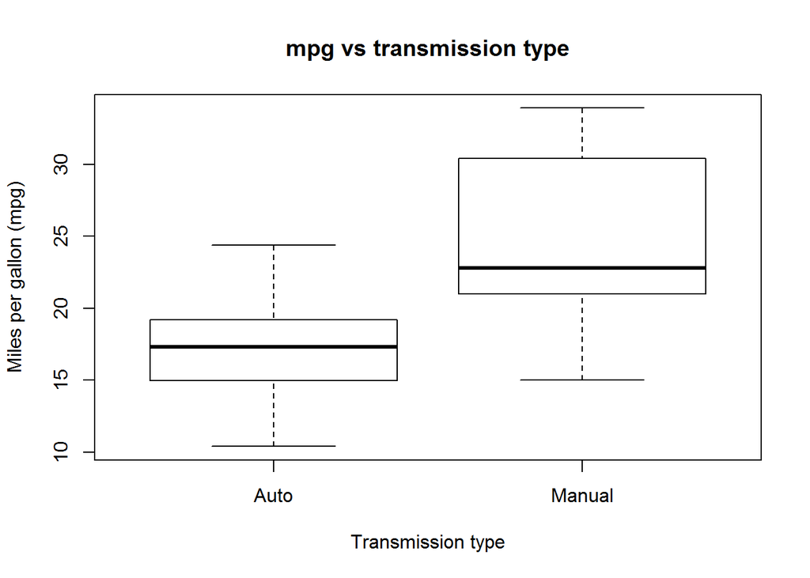

```r
mtcars$am<-factor(mtcars$am)
mtcars$cyl<-factor(mtcars$cyl)
mtcars$gear<-factor(mtcars$gear)
mtcars$carb<-factor(mtcars$carb)
mtcars$vs<-factor(mtcars$vs)
levels(mtcars$am)<-c("Auto","Manual")
boxplot(mtcars$mpg~mtcars$am,main="mpg vs transmission type",xlab="Transmission type",ylab="Miles per gallon (mpg)")
```

Now let’s see in a pairs plot how the variables in the dataset are correlated, to identify possible cofounders. It seems that the variables cyl, disp, hp and wt are highly correlated while drat is inversely correlated with the rest of them.

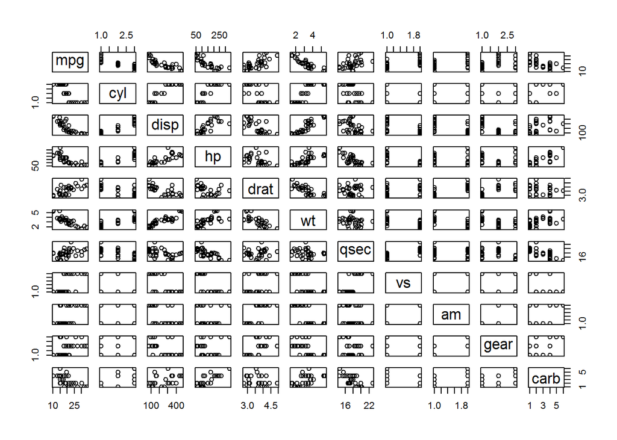

```r
pairs(mtcars)
```

### Modelling

With the information obtained in the exploratory phase we are going to detail 3 nested models. First the minimal model in which we are interested, then we are going to add disp since we have observed it is correlated with most of the other variables and finally we are going to add the rest of the variables not correlated with disp to see how much more variance they explain.

- Model 1: mpg ~ am
- Model 2: mpg ~ am + disp
- Model 3: mpg ~ am + disp + qsec + vs + gear + carb

```r
model1<-lm(mpg~am,data=mtcars)
model2<-lm(mpg~am+disp,data=mtcars)
model3<-lm(mpg~am+disp+qsec+vs+gear+carb,data=mtcars)
anova(model1,model2,model3)
```

```
## Analysis of Variance Table
##
## Model 1: mpg ~ am
## Model 2: mpg ~ am + disp
## Model 3: mpg ~ am + disp + qsec + vs + gear + carb
##   Res.Df    RSS Df Sum of Sq       F    Pr(>F)
## 1     30 720.90
## 2     29 300.28  1    420.62 47.7976 1.028e-06 ***
## 3     20 176.00  9    124.28  1.5692    0.1918
## ---
## Signif. codes:  0 '***' 0.001 '**' 0.01 '*' 0.05 '.' 0.1 ' ' 1
```

From the anova test, we can see that adding the variable disp is significant into explaining more variance of the model while adding the rest is not. So we are going to choose Model 2 from here onwards.

Finally we plot the residual plot for model 2 to try to identify any pattern in the residuals and we also perform a dfbetas test to check if there’s any point with high leverage or influence in our dataset that could be driving the analysis.

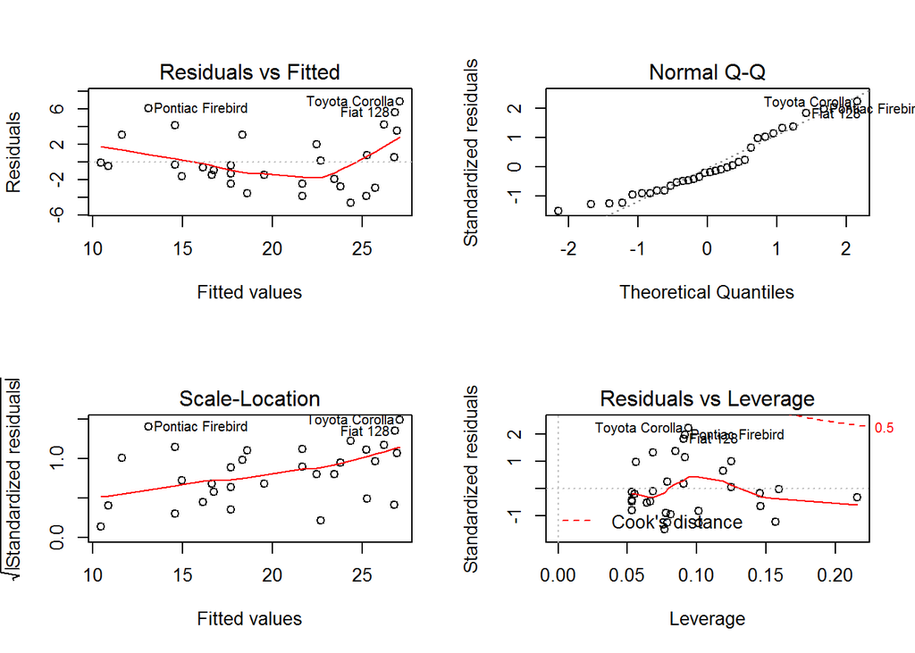

```r
par(mfrow=c(2,2))
plot(model2)
```

```r
dfbetas(model2)
```

```
##                      (Intercept)     amManual         disp
## Mazda RX4            0.025342259 -0.177611975 -0.027683828
## Mazda RX4 Wag        0.025342259 -0.177611975 -0.027683828
## Datsun 710          -0.057226952 -0.131815037  0.062514597
## Hornet 4 Drive       0.146535694 -0.153307397 -0.058553325
## Hornet Sportabout   -0.030879664 -0.061231905  0.174206660
## Valiant             -0.095595629  0.089619935  0.056184094
## Duster 360           0.002048068  0.004061155 -0.011554110
## Merc 240D            0.224754273 -0.185020263 -0.176541015
## Merc 230             0.016591725 -0.013574101 -0.013178589
## Merc 280            -0.250023566  0.211002087  0.187425962
## Merc 280C           -0.398394630  0.336216700  0.298649835
## Merc 450SE          -0.048340027  0.055445153  0.010886271
## Merc 450SL          -0.014434741  0.016556391  0.003250732
## Merc 450SLC         -0.094253249  0.108106804  0.021226020
## Cadillac Fleetwood   0.004083253 -0.001483975 -0.006456165
## Lincoln Continental  0.033147757 -0.011056922 -0.054124105
## Chrysler Imperial   -0.167546622  0.044693261  0.292944151
## Fiat 128             0.213903322  0.207589250 -0.233667522
## Honda Civic          0.134669332  0.121067025 -0.147112484
## Toyota Corolla       0.301705364  0.241630703 -0.329582281
## Toyota Corona       -0.257922923  0.206950975  0.211894303
## Dodge Challenger    -0.009549644  0.018034631 -0.010103627
## AMC Javelin         -0.032724397  0.048410771 -0.011452027
## Camaro Z28           0.003098258  0.029539484 -0.057965089
## Pontiac Firebird    -0.193781914 -0.003253700  0.433897074
## Fiat X1-9            0.018883186  0.018467678 -0.020627951
## Porsche 914-2        0.009528547  0.036826899 -0.010408964
## Lotus Europa         0.116033395  0.176117583 -0.126754628
## Ford Pantera L       0.126079479 -0.145109179 -0.137728948
## Ferrari Dino         0.003860859 -0.277857399 -0.004217594
## Maserati Bora        0.345673438 -0.453284356 -0.377612910
## Volvo 142E          -0.048237832 -0.193194688  0.052694903
```

## Conclusion

Now we are going to use model 2 to answer the questions that we stated at the start of the report: whether automatic or manual transmission is better for miles per gallon consumption and to quantify such a difference.

```r
summary(model2)
```

```
##
## Call:
## lm(formula = mpg ~ am + disp, data = mtcars)
##
## Residuals:
##     Min      1Q  Median      3Q     Max
## -4.6382 -2.4751 -0.5631  2.2333  6.8386
##
## Coefficients:
##              Estimate Std. Error t value Pr(>|t|)
## (Intercept) 27.848081   1.834071  15.184 2.45e-15 ***
## amManual     1.833458   1.436100   1.277    0.212
## disp        -0.036851   0.005782  -6.373 5.75e-07 ***
## ---
## Signif. codes:  0 '***' 0.001 '**' 0.01 '*' 0.05 '.' 0.1 ' ' 1
##
## Residual standard error: 3.218 on 29 degrees of freedom
## Multiple R-squared:  0.7333, Adjusted R-squared:  0.7149
## F-statistic: 39.87 on 2 and 29 DF,  p-value: 4.749e-09
```

We can see from the amManual coefficient of the regression that the difference from automatic to manual in the outcome mpg is of 1.83 with a standard error or 1.43. That is manual cars tend to have a higher mpg value than automatic cars. This difference is though not significant at a 95% confidence interval since the associated p-value is 0.2.

Therefore, we conclude that there is no difference in mpg with respect to transmission type (automatic or manual) at a 95% confidence interval.